# MVP for Cardiovascular

## Cardiovascular Detection & Prediction

The purpose of this project is to better understand which factors are most important in affecting on cardiovascular or heart diseases, since there are a lot of reason that will motivate us to find the best result and model so we can:

- Help patients detecting it before it might be happening
- Not time consuming & resource consumption will be low
- Helping the doctors seeing more patients who are in series danger

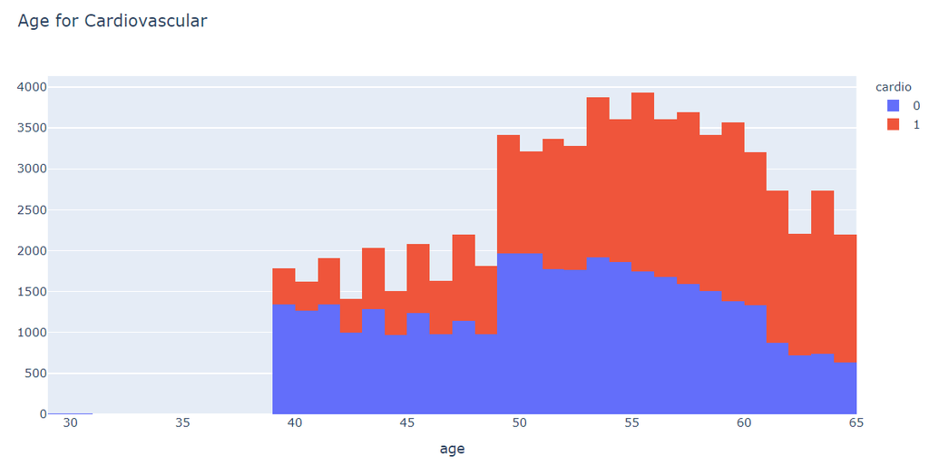

The plot above gives us an insights about the data we have, such as:

- the youngest patient in the data was nearly 30 years old
- the oldest patient was 65 years old
- a patern was noticed, that the older the patients gets the number of paitents with heart diesases, and this prove that age is a correlated factor with heart diseases

in the final submission will be diving into more detailed analysis, in addition with the final model results, since the goal of the model is to achive at least 70% of accuracy